# Exercises 3: Hypothesis Tests — Solutions

These solutions use the five fictional datasets supplied with Exercises 3. Place this file and all five CSV files in the same folder before knitting. All tests are two-sided unless otherwise stated, using alpha = 0.05.

## Exercise 1 — One-sample t-test

**1. Import and summarize.**

```r
case <- read.csv("case_processing.csv")
nrow(case)
```

```
## [1] 45
```

```r
mean(case$processing_days)
```

```
## [1] 16.95333
```

```r
sd(case$processing_days)
```

```
## [1] 4.796381
```

```r
summary(case$processing_days)
```

```
##    Min. 1st Qu.  Median    Mean 3rd Qu.    Max.
##    4.20   14.30   16.10   16.95   19.80   30.20
```

There are **45 cases**, with mean **16.95 days** and standard deviation **4.80 days**.

**2. Visualize and assess assumptions.**

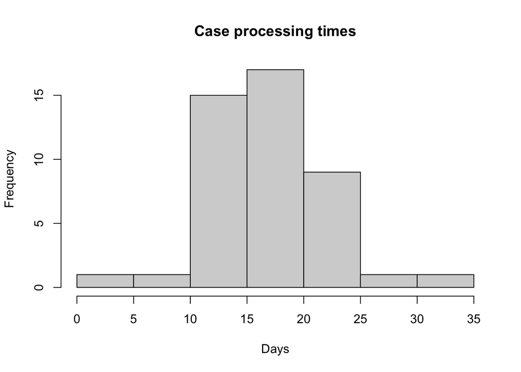

```r
hist(case$processing_days,
     main = "Case processing times", xlab = "Days")
```

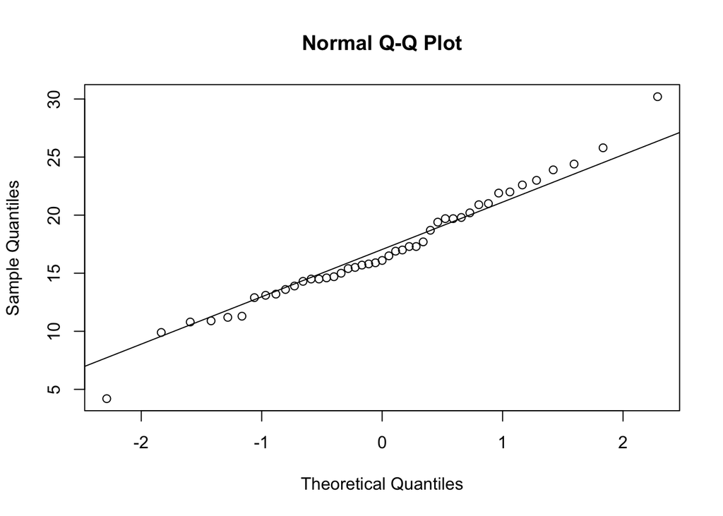

```r
qqnorm(case$processing_days)
qqline(case$processing_days)
```

This is a one-sample test of a quantitative outcome. We assume cases are independent and represent a suitable sample. Check the histogram and Q-Q plot for strong skewness or extreme outliers; minor deviations are usually tolerable with n = 45. The t-test does **not** require the raw data to be perfectly normally distributed.

**3. Hypotheses.**

H0: The population mean processing time is 20 days.

Ha: The population mean processing time is not 20 days.

**4–5. Test and interpret.**

```r
t.test(case$processing_days, mu = 20)
```

```
##
##  One Sample t-test
##
## data:  case$processing_days
## t = -4.2611, df = 44, p-value = 0.0001056
## alternative hypothesis: true mean is not equal to 20
## 95 percent confidence interval:
##  15.51234 18.39433
## sample estimates:
## mean of x
##  16.95333
```

Result: **t(44) = -4.26, p = 0.000106**, 95% confidence interval for the mean **[15.51, 18.39] days**. Reject H0. There is statistically significant evidence that the population mean processing time differs from 20 days; the observed mean is lower. This does not, by itself, establish what caused the change.

## Exercise 2 — Independent two-sample t-test

**1. Compare groups.**

```r
program <- read.csv("program_outcomes.csv")
aggregate(days_to_resolution ~ program, data = program,
          FUN = function(z) c(n = length(z), mean = mean(z), sd = sd(z)))
```

```
##       program days_to_resolution.n days_to_resolution.mean
## 1   Diversion             42.00000                63.19286
## 2 Traditional             42.00000                66.78571
##   days_to_resolution.sd
## 1              14.41374
## 2              15.75188
```

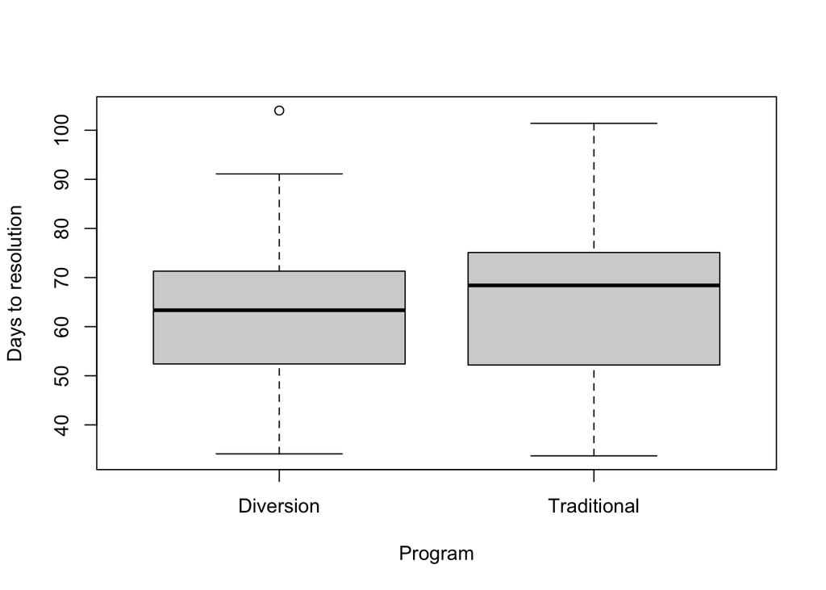

```r
boxplot(days_to_resolution ~ program, data = program,
        xlab = "Program", ylab = "Days to resolution")
```

Diversion: **n = 42, mean = 63.19, SD = 14.41 days**. Traditional: **n = 42, mean = 66.79, SD = 15.75 days**. The observed difference (Diversion minus Traditional) is approximately **-3.59 days**.

**2. Hypotheses.**

H0: The population means are equal for the two programs.

Ha: The population means differ.

**3. Assumptions.**

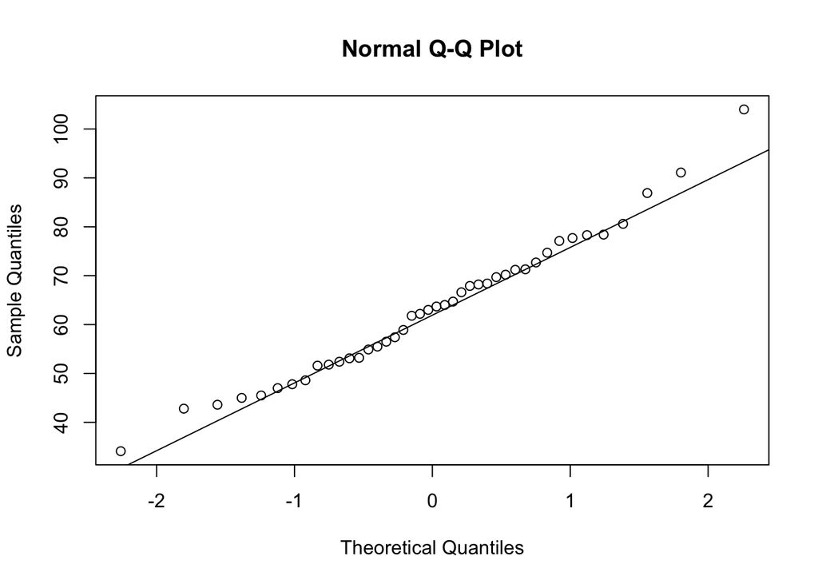

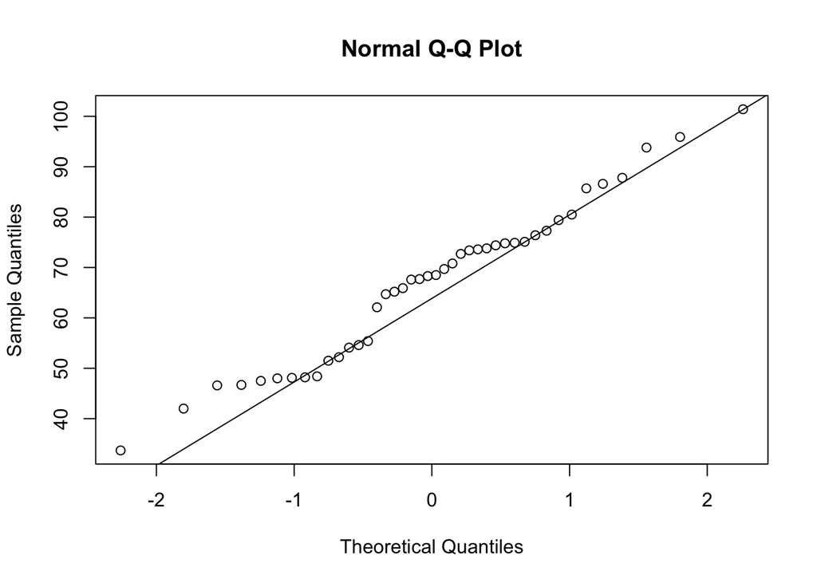

```
## program$program: Diversion
## NULL
## ------------------------------------------------------------
## program$program: Traditional
## NULL
```

```r
by(program$days_to_resolution, program$program, function(z) {
  qqnorm(z)
  qqline(z)
})
```

The outcome is quantitative; the groups contain different people, so the observations are **not paired**. Independence is supported by the sampling description but cannot be proven from a Q-Q plot. Examine each group’s distribution for major departures from normality and outliers. Welch’s test does not require equal population variances.

**4–5. Welch test and interpretation.**

```r
t.test(days_to_resolution ~ program, data = program)
```

```
##
##  Welch Two Sample t-test
##
## data:  days_to_resolution by program
## t = -1.0905, df = 81.362, p-value = 0.2787
## alternative hypothesis: true difference in means between group Diversion and group Traditional is not equal to 0
## 95 percent confidence interval:
##  -10.147587   2.961872
## sample estimates:
##   mean in group Diversion mean in group Traditional
##                  63.19286                  66.78571
```

R alphabetically orders groups as Diversion, Traditional, so the reported difference is Diversion minus Traditional. Result: **t ≈ -1.09, df ≈ 81.36, p ≈ 0.279**. Fail to reject H0. The sample suggests slightly shorter resolution times in diversion, but there is insufficient evidence of a difference in population means. Inspect the printed 95% confidence interval: it includes zero. Failure to reject H0 is not evidence that the two programs have identical means.

## Exercise 3 — Paired t-test

**1–2. Compute and explore within-officer differences.**

```r
training <- read.csv("training_scores.csv")
training$difference <- training$score_after - training$score_before
summary(training$difference)
```

```
##    Min. 1st Qu.  Median    Mean 3rd Qu.    Max.
## -13.900  -6.800  -4.700  -4.956  -2.300   1.400
```

```r
mean(training$difference)
```

```
## [1] -4.955556
```

```r
sd(training$difference)
```

```
## [1] 3.57087
```

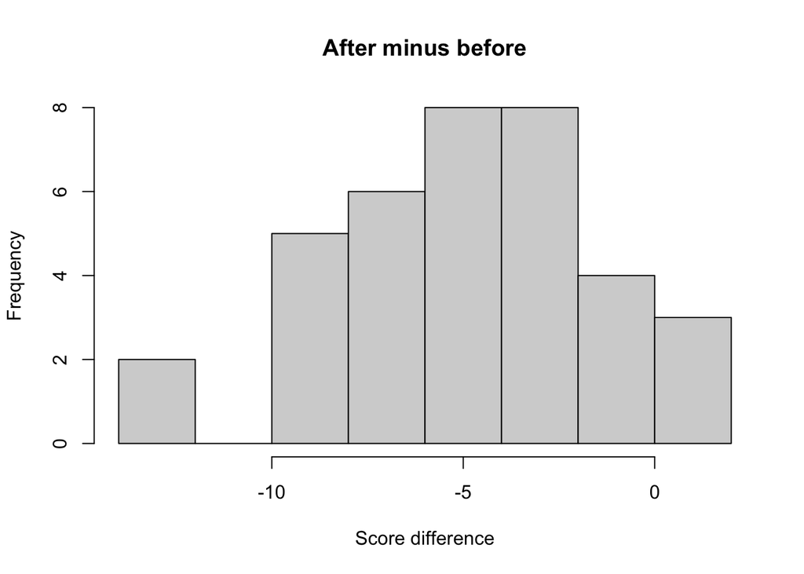

```r
hist(training$difference,
     main = "After minus before", xlab = "Score difference")
```

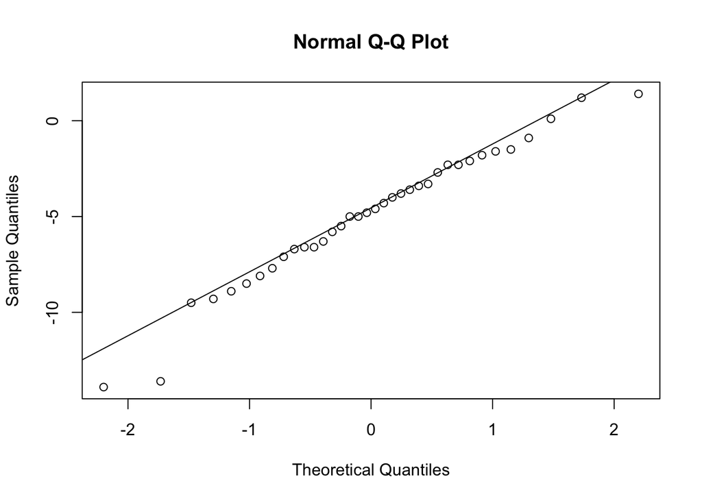

```r
qqnorm(training$difference)
qqline(training$difference)
```

There are **36 paired observations**. The mean after-minus-before difference is **-4.96 points**, and the SD of the differences is **3.57 points**. The negative mean indicates that scores were, on average, *lower* after training. This is an unexpected but valid finding to report.

**3. Hypotheses.**

H0: The population mean of (after − before) is zero.

Ha: The population mean of (after − before) is not zero.

**4–5. Paired test and interpretation.**

```r
t.test(training$score_after, training$score_before,
       paired = TRUE)
```

```
##
##  Paired t-test
##
## data:  training$score_after and training$score_before
## t = -8.3266, df = 35, p-value = 8.103e-10
## alternative hypothesis: true mean difference is not equal to 0
## 95 percent confidence interval:
##  -6.163764 -3.747347
## sample estimates:
## mean difference
##       -4.955556
```

```r
# Equivalent:
t.test(training$difference, mu = 0)
```

```
##
##  One Sample t-test
##
## data:  training$difference
## t = -8.3266, df = 35, p-value = 8.103e-10
## alternative hypothesis: true mean is not equal to 0
## 95 percent confidence interval:
##  -6.163764 -3.747347
## sample estimates:
## mean of x
## -4.955556
```

Result: **t(35) = -8.33, p ≈ 8.10e-10**, 95% confidence interval for mean change **[-6.16, -3.75] points**. Reject H0. Scores are significantly different before and after training, with an average decrease of about five points. Normality should be assessed for the **differences**, not for each time point separately. An independent two-sample t-test is inappropriate because the two scores from the same officer are related. Even a statistically significant pre/post change alone cannot establish that training caused the change.

## Exercise 4 — One-way ANOVA

**1. Summaries and plot.**

```r
satisfaction <- read.csv("service_satisfaction.csv")
aggregate(satisfaction_score ~ contact_method, data = satisfaction,
          FUN = function(z) c(n = length(z), mean = mean(z), sd = sd(z)))
```

```
##   contact_method satisfaction_score.n satisfaction_score.mean
## 1          Email            32.000000                7.734375
## 2       InPerson            32.000000                8.634375
## 3          Phone            32.000000                6.606250
##   satisfaction_score.sd
## 1              1.179560
## 2              1.298041
## 3              1.068595
```

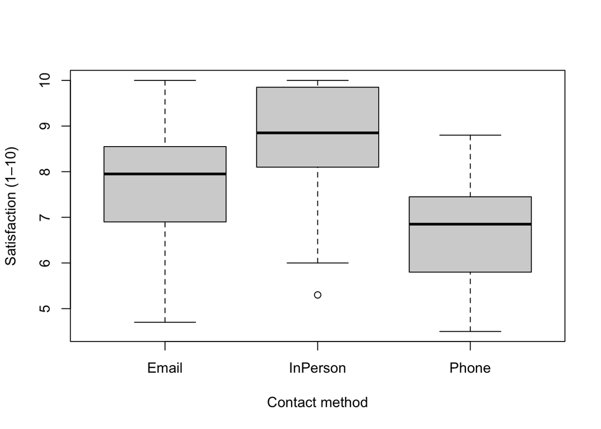

```r
boxplot(satisfaction_score ~ contact_method, data = satisfaction,
        xlab = "Contact method", ylab = "Satisfaction (1–10)")
```

Email: **n = 32, mean = 7.73, SD = 1.18**. In-person: **n = 32, mean = 8.63, SD = 1.30**. Phone: **n = 32, mean = 6.61, SD = 1.07**.

**2. Hypotheses.**

H0: The population mean satisfaction is the same for Email, InPerson, and Phone.

Ha: At least one population mean differs.

**3–4. Fit ANOVA and examine diagnostics.**

```r
fit <- aov(satisfaction_score ~ contact_method, data = satisfaction)
summary(fit)
```

```
##                Df Sum Sq Mean Sq F value   Pr(>F)
## contact_method  2  66.09   33.05    23.5 5.48e-09 ***
## Residuals      93 130.76    1.41
## ---
## Signif. codes:  0 '***' 0.001 '**' 0.01 '*' 0.05 '.' 0.1 ' ' 1
```

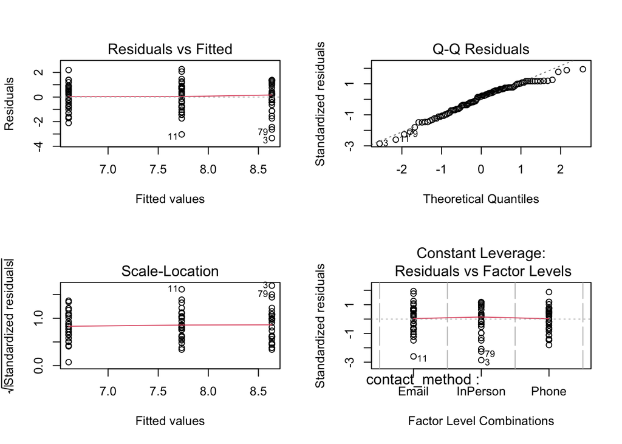

```r
par(mfrow = c(2, 2))
plot(fit)
```

```r
par(mfrow = c(1, 1))
```

The outcome is treated as quantitative and respondents are assumed independent. Examine residuals versus fitted values for similar spreads, and the Q-Q plot for strong residual nonnormality. There are equally sized groups (32 each) with relatively similar sample SDs. Still, a 1–10 rating is bounded and discrete, so normal-model assumptions are only approximate; note ceiling effects if visible. ANOVA assumes the population variances are equal; the ordinary ANOVA in `aov()` does not automatically relax that assumption.

Result: **F(2, 93) = 23.50, p ≈ 5.48e-09**. Reject H0. At least one population mean satisfaction score differs across methods. This **does not** show that every pair differs or identify which pair differs.

**5. Tukey comparisons.**

```r
TukeyHSD(fit)
```

```
##   Tukey multiple comparisons of means
##     95% family-wise confidence level
##
## Fit: aov(formula = satisfaction_score ~ contact_method, data = satisfaction)
##
## $contact_method
##                     diff        lwr        upr     p adj
## InPerson-Email  0.900000  0.1939282  1.6060718 0.0086553
## Phone-Email    -1.128125 -1.8341968 -0.4220532 0.0007348
## Phone-InPerson -2.028125 -2.7341968 -1.3220532 0.0000000
```

Use the Tukey-adjusted p-values and confidence intervals to identify statistically distinguishable pairs. In these data, the ordering of sample means is **InPerson > Email > Phone**. See the R output for which specific pairwise differences are statistically significant after multiplicity adjustment. Group differences do not necessarily reflect causal effects of the contact method.

## Exercise 5 — Chi-square test of independence

**1. Contingency table, percentages, plot.**

```r
survey <- read.csv("survey_responses.csv")
tab <- table(survey$residence, survey$supports_policy)
tab
```

```
##
##            No Yes
##   Suburban 40  20
##   Urban    25  35
```

```r
round(100 * prop.table(tab, margin = 1), 1)
```

```
##
##              No  Yes
##   Suburban 66.7 33.3
##   Urban    41.7 58.3
```

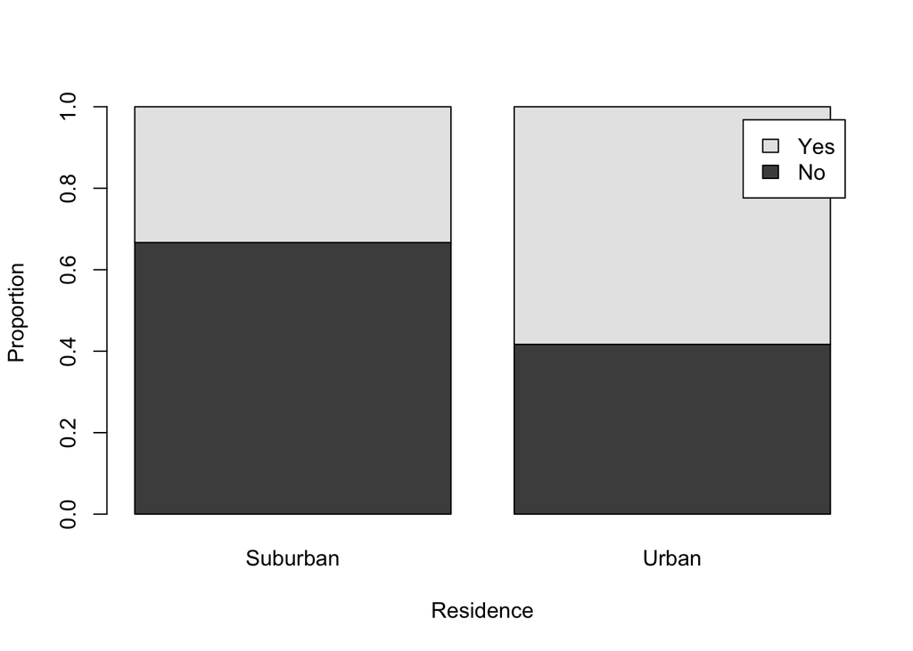

```r
barplot(t(prop.table(tab, margin = 1)), beside = FALSE,
        legend.text = TRUE, ylab = "Proportion", xlab = "Residence")
```

The rows are residence groups. In the suburban group, **20/60 = 33.3%** support the policy; in the urban group, **35/60 = 58.3%** support it.

**2. Hypotheses.**

H0: Residence and policy support are independent in the population.

Ha: Residence and policy support are associated.

**3–4. Expected counts and Pearson test.**

```r
chi <- chisq.test(tab, correct = FALSE)
chi$expected
```

```
##
##              No  Yes
##   Suburban 32.5 27.5
##   Urban    32.5 27.5
```

```r
chi
```

```
##
##  Pearson's Chi-squared test
##
## data:  tab
## X-squared = 7.5524, df = 1, p-value = 0.005993
```

Observed counts: Suburban (No = 40, Yes = 20); Urban (No = 25, Yes = 35). Expected counts under independence: each residence group has **32.5 No** and **27.5 Yes**. All expected counts exceed five. Each respondent is counted once; independence of respondents comes from the design assumption, not from the table itself. Use counts, not percentages, in `chisq.test()`.

**5. Interpret.**

Result: **chi-square(1) = 7.55, p ≈ 0.00599**. Reject H0. Residence type and policy support are statistically associated in these data. Support is higher among urban respondents (58.3%) than suburban respondents (33.3%). The test does not establish that residence *causes* support, as other characteristics may differ between the groups.

## Instructor note

With a 2-by-2 table, `chisq.test(tab)` in R applies Yates’s continuity correction by default. We use `correct = FALSE` as the exercise specifies, so the statistic is the usual Pearson chi-square statistic. A Fisher exact test is an alternative when expected cell counts are small, but is unnecessary here.